# Reproducible Research: Peer Assessment 1

## Imputing missing values

```r
missingAbs <- sum(!complete.cases(activity))
missingRel <- mean(!complete.cases(activity))
```

The total number of incomplete cases in the dataset (i.e. the total number of rows with NAs) amounts to 2304 or 13%.

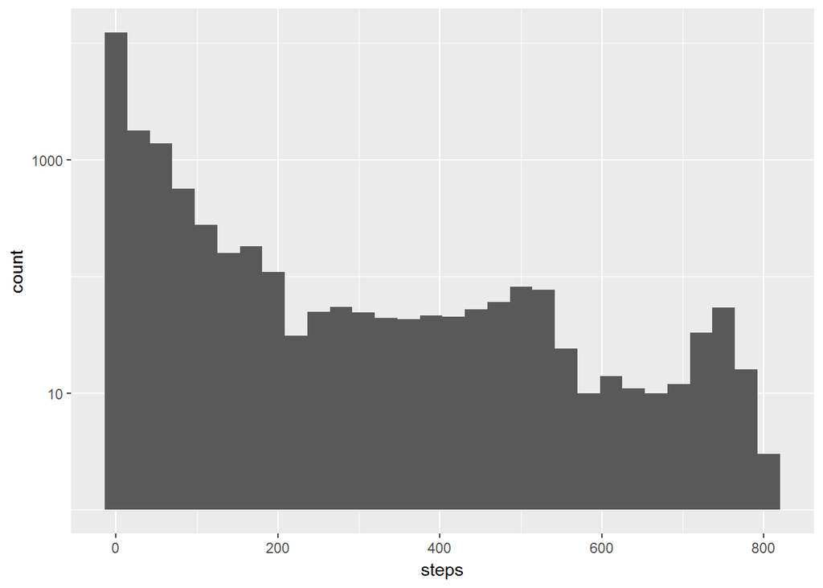

```r
iMissing <- which(is.na(activity$steps))
intervalMissing <- activity$interval[iMissing]
stepsMissing <- intervalSteps$steps[match(intervalMissing,intervalSteps$interval)]
activityInterp <- activity
activityInterp$steps[is.na(activity$steps)] <- stepsMissing

ggplot(activityInterp, aes(steps)) +
geom_histogram()+ scale_y_log10()
```

```r
meanStepsInterp <- mean(activityInterp$steps, na.rm = TRUE)
medianStepsInterp <- median(activityInterp$steps, na.rm = TRUE)
totalDaily <- mean(aggregate( steps ~ date, activity, sum )$steps)
totalDailyInterp <- mean(aggregate( steps ~ date, activityInterp, sum )$steps)
```

There is no impact of inputing missing data on the estimates of the total daily number of steps (previously 10766, now 10766)

## Are there differences in activity patterns between weekdays and weekends?

For this part the weekdays() function may be of some help here. Use the dataset with the filled-in missing values for this part.

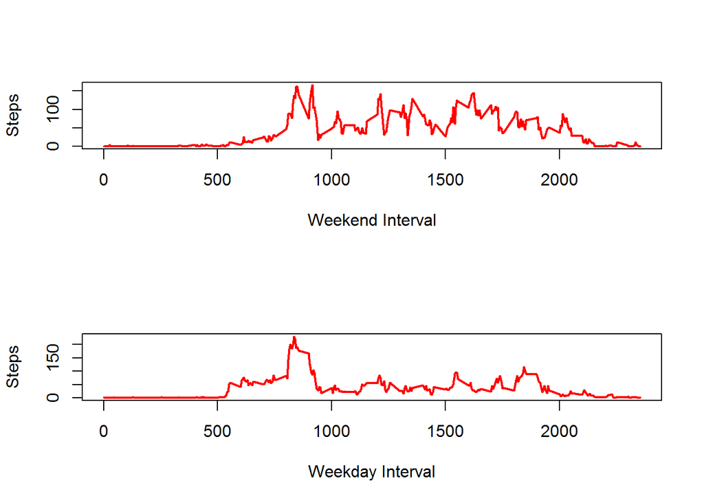

```r
weekEndDays <- c('Samstag', 'Sonntag')
#Use `%in%` and `weekdays` to create a logical vector
#convert to `factor` and specify the `levels/labels`
activityInterp$wDay <- factor((weekdays(activityInterp$date) %in% weekEndDays), levels=c(TRUE, FALSE), labels=c('weekend', 'weekday'))
par(mfrow=c(2,1))
intervalStepsWeekend <- aggregate( steps ~ interval, activityInterp[activityInterp$wDay == 'weekend',], mean )
plot(intervalStepsWeekend, type='l',xlab= 'Weekend Interval', ylab='Steps', col='red' , lwd=2)
intervalStepsWeekday <- aggregate( steps ~ interval, activityInterp[activityInterp$wDay == 'weekday',], mean )
plot(intervalStepsWeekday, type='l',xlab= 'Weekday Interval', ylab='Steps', col='red' , lwd=2)
```